# R Notebook

Modelo parametricos:

# Metodos de los K-vecinos mas cercanos:

- Definir la k instancias que estan mas cercas de. Se escoge usualmente un valor impara de k
- Toma las k vecinos mas cercanos, si la variable a predecir es categorica, se observa cual es la moda.
- La probabilidad se basa es la frecuencia.
- Es un clasificador ocioso, calcula todas ls distancias, toma tiempo para el calculo
- El valor k es un hiperparametro, porque se tiene que definir
- Para el caso de las distancias, deben ser cuantitativas, en caso se tenga valores cualitativos no se puede usar las distancias, se recomienda dicomotomizar las variable categorica.
- La distancia de Boogle trabaja con distancias absolutas
- Se suele usar kernel para asignar pesos

# Regresion Logistica ( Multinomial)

- Se define primero la probabildad
- No se estima

#——————————————————————# # K-NN # #——————————————————————#

# # Ejemplo: Diabetes #

```r
diabetes=read.csv("DiabetesTrain.csv")
#diabetes=read.csv(file.choose())
head(diabetes)
```

|  | glucose | insulin | sspg | class |
| --- | --- | --- | --- | --- |
| 1 | 97 | 289 | 117 | normal |
| 2 | 105 | 319 | 143 | normal |
| 3 | 90 | 356 | 199 | normal |
| 4 | 90 | 323 | 240 | normal |
| 5 | 86 | 381 | 157 | normal |
| 6 | 100 | 350 | 221 | normal |

```r
table(diabetes$class)
```

```
chemical   normal    overt
      26       66       23
```

chemical –> Diagnostico que tiene Diabetes - Tenemos un problema politonico

```r
library(class)
b<-knn(train = diabetes[,1:3],test = diabetes[,1:3],cl = diabetes[,4])
##
b
```

```
  [1] normal   normal   normal   normal   normal   normal   normal   normal
  [9] normal   normal   normal   normal   normal   normal   normal   normal
 [17] normal   normal   normal   normal   normal   normal   normal   normal
 [25] normal   normal   normal   normal   normal   normal   normal   normal
 [33] normal   normal   normal   normal   normal   normal   normal   normal
 [41] normal   normal   normal   normal   normal   normal   normal   normal
 [49] normal   chemical normal   normal   chemical normal   chemical normal
 [57] normal   normal   normal   normal   normal   normal   normal   chemical
 [65] normal   normal   normal   normal   normal   chemical normal   chemical
 [73] chemical chemical chemical chemical chemical chemical chemical chemical
 [81] chemical chemical chemical chemical chemical chemical chemical chemical
 [89] chemical chemical chemical chemical overt    overt    overt    overt
 [97] overt    overt    overt    overt    overt    overt    overt    overt
[105] overt    overt    overt    overt    overt    overt    overt    overt
[113] overt    overt    overt
Levels: chemical normal overt
```

Nos muestra los valores predichos con los natureles

```r
#Estimacion del error por resubstituci?n
confusionMatrix(b,diabetes[,4])
```

```
Confusion Matrix and Statistics

          Reference
Prediction chemical normal overt
  chemical       26      0     0
  normal          0     66     0
  overt           0      0    23

Overall Statistics

               Accuracy : 1
                 95% CI : (0.9684, 1)
    No Information Rate : 0.5739
    P-Value [Acc > NIR] : < 2.2e-16

                  Kappa : 1

 Mcnemar's Test P-Value : NA

Statistics by Class:

                     Class: chemical Class: normal Class: overt
Sensitivity                   1.0000        1.0000          1.0
Specificity                   1.0000        1.0000          1.0
Pos Pred Value                1.0000        1.0000          1.0
Neg Pred Value                1.0000        1.0000          1.0
Prevalence                    0.2261        0.5739          0.2
Detection Rate                0.2261        0.5739          0.2
Detection Prevalence          0.2261        0.5739          0.2
Balanced Accuracy             1.0000        1.0000          1.0
```

El Accuracty es 1 porque el k es 1 y la data de entrenamiento y validacion es la misma.

```r
# con K=3
k_3 <- knn(train = diabetes[,1:3],test = diabetes[,1:3],cl = diabetes[,4], k = 3)
confusionMatrix(k_3,diabetes[,4])
```

```
Confusion Matrix and Statistics

          Reference
Prediction chemical normal overt
  chemical       25      1     4
  normal          1     65     0
  overt           0      0    19

Overall Statistics

               Accuracy : 0.9478
                 95% CI : (0.8899, 0.9806)
    No Information Rate : 0.5739
    P-Value [Acc > NIR] : < 2.2e-16

                  Kappa : 0.9098

 Mcnemar's Test P-Value : NA

Statistics by Class:

                     Class: chemical Class: normal Class: overt
Sensitivity                   0.9615        0.9848       0.8261
Specificity                   0.9438        0.9796       1.0000
Pos Pred Value                0.8333        0.9848       1.0000
Neg Pred Value                0.9882        0.9796       0.9583
Prevalence                    0.2261        0.5739       0.2000
Detection Rate                0.2174        0.5652       0.1652
Detection Prevalence          0.2609        0.5739       0.1652
Balanced Accuracy             0.9527        0.9822       0.9130
```

```r
mean(k_3 == diabetes[,4])
```

```
[1] 0.9478261
```

```r
# con K=7
k_7 <- knn(train = diabetes[,1:3],test = diabetes[,1:3],cl = diabetes[,4], k = 7)
confusionMatrix(k_7,diabetes[,4])
```

```
Confusion Matrix and Statistics

          Reference
Prediction chemical normal overt
  chemical       22      1     5
  normal          4     65     0
  overt           0      0    18

Overall Statistics

               Accuracy : 0.913
                 95% CI : (0.8459, 0.9575)
    No Information Rate : 0.5739
    P-Value [Acc > NIR] : 8.022e-16

                  Kappa : 0.8473

 Mcnemar's Test P-Value : NA

Statistics by Class:

                     Class: chemical Class: normal Class: overt
Sensitivity                   0.8462        0.9848       0.7826
Specificity                   0.9326        0.9184       1.0000
Pos Pred Value                0.7857        0.9420       1.0000
Neg Pred Value                0.9540        0.9783       0.9485
Prevalence                    0.2261        0.5739       0.2000
Detection Rate                0.1913        0.5652       0.1565
Detection Prevalence          0.2435        0.6000       0.1565
Balanced Accuracy             0.8894        0.9516       0.8913
```

```r
mean(k_7 == diabetes[,4])
```

```
[1] 0.9130435
```

```r
# con K=15
k_15 <- knn(train = diabetes[,1:3],test = diabetes[,1:3],cl = diabetes[,4], k = 15)
confusionMatrix(k_15,diabetes[,4])
```

```
Confusion Matrix and Statistics

          Reference
Prediction chemical normal overt
  chemical       20      1     5
  normal          6     65     0
  overt           0      0    18

Overall Statistics

               Accuracy : 0.8957
                 95% CI : (0.8248, 0.9449)
    No Information Rate : 0.5739
    P-Value [Acc > NIR] : 3.778e-14

                  Kappa : 0.8147

 Mcnemar's Test P-Value : NA

Statistics by Class:

                     Class: chemical Class: normal Class: overt
Sensitivity                   0.7692        0.9848       0.7826
Specificity                   0.9326        0.8776       1.0000
Pos Pred Value                0.7692        0.9155       1.0000
Neg Pred Value                0.9326        0.9773       0.9485
Prevalence                    0.2261        0.5739       0.2000
Detection Rate                0.1739        0.5652       0.1565
Detection Prevalence          0.2261        0.6174       0.1565
Balanced Accuracy             0.8509        0.9312       0.8913
```

```r
mean(k_15 == diabetes[,4])
```

```
[1] 0.8956522
```

```r
## Usando validaci?n cruzada
set.seed(007)
mean(knn.cv(train = diabetes[,1:3],cl = diabetes[,4],k=1)==diabetes[,4])
```

```
[1] 0.8869565
```

```r
mean(knn.cv(train = diabetes[,1:3],cl = diabetes[,4],k=3)==diabetes[,4])
```

```
[1] 0.9043478
```

```r
mean(knn.cv(train = diabetes[,1:3],cl = diabetes[,4],k=5)==diabetes[,4])
```

```
[1] 0.8956522
```

```r
mean(knn.cv(train = diabetes[,1:3],cl = diabetes[,4],k=7)==diabetes[,4])
```

```
[1] 0.8956522
```

```r
mean(knn.cv(train = diabetes[,1:3],cl = diabetes[,4],k=9)==diabetes[,4])
```

```
[1] 0.8956522
```

```r
mean(knn.cv(train = diabetes[,1:3],cl = diabetes[,4],k=11)==diabetes[,4])
```

```
[1] 0.8869565
```

```r
mean(knn.cv(train = diabetes[,1:3],cl = diabetes[,4],k=13)==diabetes[,4])
```

```
[1] 0.8956522
```

```r
mean(knn.cv(train = diabetes[,1:3],cl = diabetes[,4],k=15)==diabetes[,4])
```

```
[1] 0.8782609
```

Se elije el valor de k=3 porque es el que tiene el mejor valor de media

```r
K_3 <- knn(train = diabetes[,1:3],test = diabetes[,1:3],cl = diabetes[,4], k = 3, prob = TRUE)
confusionMatrix(K_3,diabetes[,4])
```

```
Confusion Matrix and Statistics

          Reference
Prediction chemical normal overt
  chemical       25      1     4
  normal          1     65     0
  overt           0      0    19

Overall Statistics

               Accuracy : 0.9478
                 95% CI : (0.8899, 0.9806)
    No Information Rate : 0.5739
    P-Value [Acc > NIR] : < 2.2e-16

                  Kappa : 0.9098

 Mcnemar's Test P-Value : NA

Statistics by Class:

                     Class: chemical Class: normal Class: overt
Sensitivity                   0.9615        0.9848       0.8261
Specificity                   0.9438        0.9796       1.0000
Pos Pred Value                0.8333        0.9848       1.0000
Neg Pred Value                0.9882        0.9796       0.9583
Prevalence                    0.2261        0.5739       0.2000
Detection Rate                0.2174        0.5652       0.1652
Detection Prevalence          0.2609        0.5739       0.1652
Balanced Accuracy             0.9527        0.9822       0.9130
```

```r
mean(K_3 == diabetes[,4])
```

```
[1] 0.9478261
```

```r
# Obtener la pro. de votos
K_3_prob <- attr(K_3, "prob")
```

```r
# Valores predichos
head(K_3)
```

```
[1] normal normal normal normal normal normal
Levels: chemical normal overt
```

```r
# Prop. de "votos"
head(K_3_prob)
```

```
[1] 1 1 1 1 1 1
```

```r
#===============================================================================
# Usando Caret
#===============================================================================
# N?mero de repeticiones y semilla
k <- 10
repeticiones <- 5
hiperparametros <- data.frame(k = c(1, 3, 5, 7, 9,  11, 13, 15, 17, 21, 31, 51))

set.seed(666)
seeds <- vector(mode = "list", length = (k * repeticiones) + 1)
for (i in 1:(k * repeticiones)) {
  seeds[[i]] <- sample.int(1000, nrow(hiperparametros))
}
seeds[[(k * repeticiones) + 1]] <- sample.int(1000, 1)
```

```r
# AJUSTE DEL MODELO

# ==============================================================================
cvmod.knn <-train(class ~.,
                    data = diabetes,
                    method = "knn",
                    tuneGrid = hiperparametros,
                    metric = "Accuracy",
                    trControl = trainControl(method = "repeatedcv",
                                             number = k, seeds = seeds,
                                             repeats = repeticiones, returnResamp = "final")
)
cvmod.knn
```

```
k-Nearest Neighbors

115 samples
  3 predictor
  3 classes: 'chemical', 'normal', 'overt'

No pre-processing
Resampling: Cross-Validated (10 fold, repeated 5 times)
Summary of sample sizes: 104, 104, 103, 104, 104, 104, ...
Resampling results across tuning parameters:

  k   Accuracy   Kappa
   1  0.8907902  0.8111758
   3  0.9060186  0.8333466
   5  0.8955338  0.8109361
   7  0.8932005  0.8049327
   9  0.8948671  0.8092228
  11  0.8931026  0.8059473
  13  0.8881096  0.7962013
  15  0.8810326  0.7830795
  17  0.8795175  0.7799287
  21  0.8548881  0.7296563
  31  0.8091352  0.6374584
  51  0.6673403  0.2994438

Accuracy was used to select the optimal model using the largest value.
The final value used for the model was k = 3.
```

```r
cvmod.knn$bestTune
```

|  | k |
| --- | --- |
| 2 | 3 |

```r
NA
```

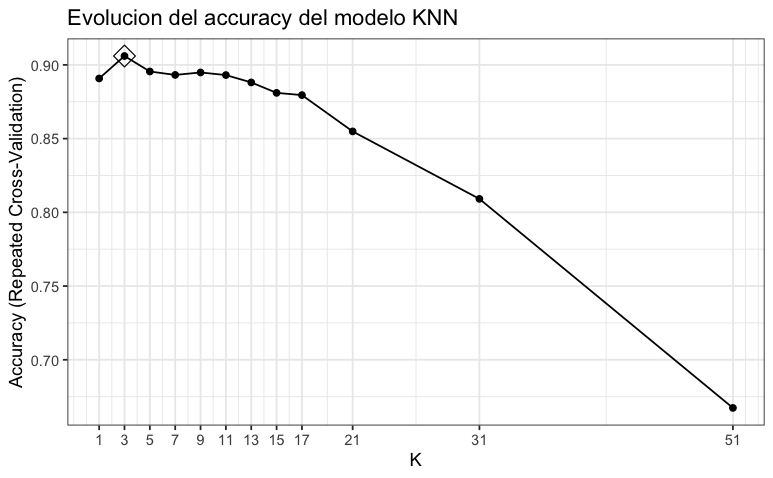

```r
library(ggplot2)
ggplot(cvmod.knn , highlight = TRUE) +
  scale_x_continuous(breaks = hiperparametros$k) +
  labs(title = "Evolucion del accuracy del modelo KNN", x = "K") +
  theme_bw()
```

Revisar los script : regresion_red.R

===============

Base de datos admision : binary.csv

admit, gre, gpa, rank

Se desea saber si alguien puede ser admitido

rank : es cardina , categorica